# P8130 Final Project

12/17/2020

```r
knitr::opts_chunk$set(
  echo = TRUE,
  include = TRUE,
  message = FALSE,
  warning = FALSE,
  fig.width = 12,
  fig.asp = .6,
  fig.align = "center",
  out.width = "90%"
)

library(tidyverse)
library(dplyr)
library(arsenal)
library(HH)
library(leaps)
library(corrplot)
library(faraway)
library(ggpubr)
library(broom)
library(ggplot2)
library(MASS)
library(patchwork)
```

Load Data Set

```r
hate_crime = read_csv("data/HateCrimes.csv", col_types = "fffdddddd") %>%
  janitor::clean_names() %>%
  drop_na()
```

# Data Exploration:

## Descriptive statistics: Table 1

Descriptive Statistics: Hate Crime Rate After 2016 Election

|  | Overall (N=45) |
| --- | --- |
| Level of unemployment |  |
| - high | 23 (51.1%) |
| - low | 22 (48.9%) |
| Level of state urbanization |  |
| - low | 21 (46.7%) |
| - high | 24 (53.3%) |
| Median Household Income |  |
| - Mean (SD) | 55299.49 (8979.49) |
| - Median (Q1, Q3) | 54916.00 (48060.00, 60708.00) |
| - Min - Max | 39552.00 - 76165.00 |
| Percent of adults with a high school degree |  |
| - Mean (SD) | 0.87 (0.03) |
| - Median (Q1, Q3) | 0.87 (0.84, 0.89) |
| - Min - Max | 0.80 - 0.92 |
| Percent of population that are not US citizens |  |
| - Mean (SD) | 0.06 (0.03) |
| - Median (Q1, Q3) | 0.05 (0.03, 0.08) |
| - Min - Max | 0.01 - 0.13 |
| Income inequality index |  |
| - Mean (SD) | 0.46 (0.02) |
| - Median (Q1, Q3) | 0.46 (0.44, 0.47) |
| - Min - Max | 0.42 - 0.53 |
| Percent of population that are non-white |  |
| - Mean (SD) | 0.32 (0.15) |
| - Median (Q1, Q3) | 0.30 (0.21, 0.42) |
| - Min - Max | 0.06 - 0.63 |
| Hate crime rate per 100,000 population |  |
| - Mean (SD) | 0.30 (0.25) |
| - Median (Q1, Q3) | 0.23 (0.14, 0.35) |
| - Min - Max | 0.07 - 1.52 |

## Visualization

##### Histogram of Outcome Variable

From the histogram below, we observe our outcome distribution has right skewness, suggesting that we may need to check our normality assumption. Our QQ Plot also indicates severe departures from normality.

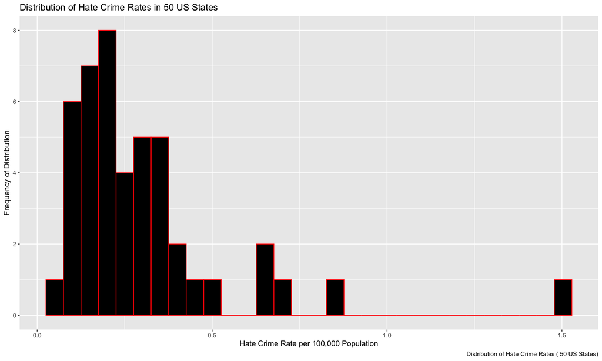

```r
#Histogram of Outcome Distribution
hate_crime %>%
  ggplot(aes(x = hate_crimes_per_100k_splc)) +
  geom_histogram(color = "red", fill = "black") +
  labs(
    title = "Distribution of Hate Crime Rates in 50 US States",
    x = "Hate Crime Rate per 100,000 Population",
    y = "Frequency of Distribution",
    caption = "Distribution of Hate Crime Rates ( 50 US States)")
```

##### QQ Plot of Outcome Variable

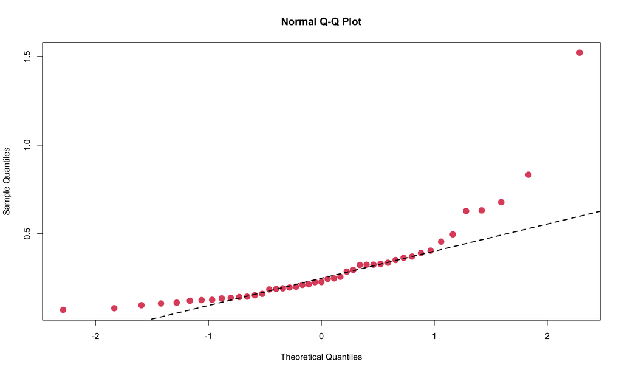

```r
#QQplot of Outcome Distribution
hate_crimes_per_100k_splc = hate_crime$hate_crimes_per_100k_splc
qqnorm(hate_crimes_per_100k_splc, col = 2, pch = 19, cex = 1.5)
qq_plot = qqline(hate_crimes_per_100k_splc, col = 1,lwd = 2,lty = 2)
```

##### Shapiro-Wilk Test of Outcome Variable

After performing a Shapiro-Wilk test to check the normality assumption of our outcome distribution, we find evidence to suggest that our data deviates from normality.

```r
# Perform Shapiro-Wilk test
shapiro.test(hate_crimes_per_100k_splc) %>%
  broom::tidy() %>%
  knitr::kable("simple")
```

| statistic | p.value | method |
| --- | --- | --- |
| 0.7107896 | 0 | Shapiro-Wilk normality test |

##### Comparison of Basic Transformations

We apply a square root transformation and a natural log transformation to our outcome distribution, and compare the results of the data.

```r
sqrt_transformation = hate_crime %>%
  ggplot(aes(x = sqrt(hate_crimes_per_100k_splc))) +
  geom_histogram(color = "red", fill = "black") +
  labs(
    title = "Distribution of sqrt(Hate Crime Rates) in 50 US States",
    x = "sqrt(Hate Crime Rate per 100,000 Population)",
    y = "Frequency of Distribution",
    caption = "Distribution of Hate Crime Rates ( 50 US States)")

sqrt_qqplot = ggplot(hate_crime, aes(sample = sqrt(hate_crimes_per_100k_splc))) + stat_qq() + stat_qq_line() +
  labs(
    title = "QQ Plot of sqrt(Hate Crime Rates) in 50 US States",
    x = "sqrt(Hate Crime Rate per 100,000 Population)",
    y = "Frequency of Distribution",
    caption = "Distribution of Hate Crime Rates ( 50 US States)")

ln_transformation = hate_crime %>%
  ggplot(aes(x = log(hate_crimes_per_100k_splc))) +
  geom_histogram(color = "red", fill = "black") +
  labs(
    title = "Distribution of ln(Hate Crime Rates) in 50 US States",
    x = "ln(Hate Crime Rate per 100,000 Population)",
    y = "Frequency of Distribution",
    caption = "Distribution of Hate Crime Rates ( 50 US States)")

ln_qqplot = ggplot(hate_crime, aes(sample = log(hate_crimes_per_100k_splc))) + stat_qq() + stat_qq_line() +
  labs(
    title = "QQ Plot of ln(Hate Crime Rates) in 50 US States",
    x = "ln(Hate Crime Rate per 100,000 Population)",
    y = "Frequency of Distribution",
    caption = "Distribution of Hate Crime Rates ( 50 US States)")
```

##### Sqrt vs. Ln Transformations

After visual inspection, we observe that our natural log transformation may be a good candidate to re-test our normality assumptions.

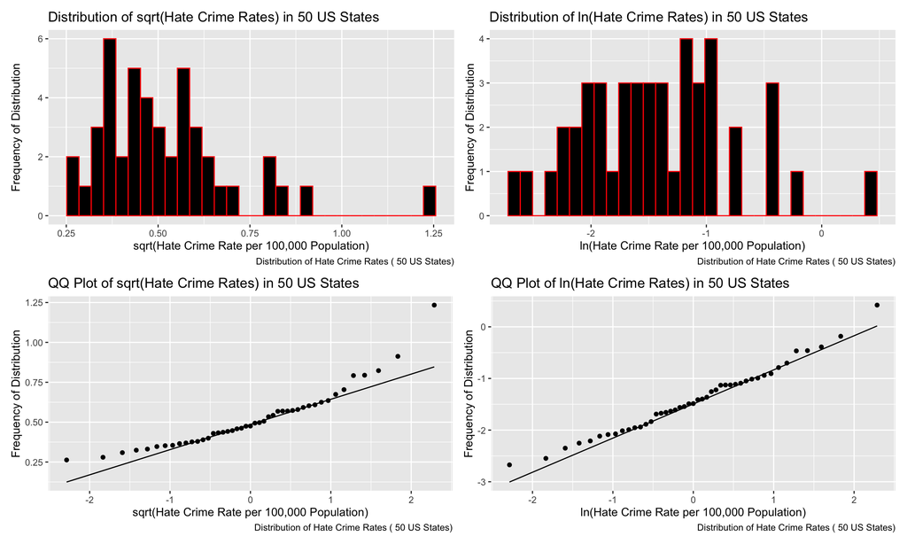

```r
(sqrt_transformation + ln_transformation) / ( sqrt_qqplot + ln_qqplot)
```

##### Shapiro-Wilk Test on our Natural Log Transformation

From the results of our test, we observe that we fail to reject the null (our p-value > 0.05) and can state with 95% confidence that our natural log transformation does not significantly deviate from normality, so we can assume normality henceforth.

```r
shapiro.test(log(hate_crimes_per_100k_splc)) %>%
  broom::tidy() %>%
  knitr::kable("simple", caption = "Shapiro Wilk Test")
```

Shapiro Wilk Test

| statistic | p.value | method |
| --- | --- | --- |
| 0.9830847 | 0.7452961 | Shapiro-Wilk normality test |

```r
hate_crime = hate_crime %>%
  mutate(
    ln_hate_crimes_per_100k_splc = log(hate_crimes_per_100k_splc)
)
```

# Income inequality was the main predictor of hate crime rates

##### Associations b/w Predictors and Hate Crime Rate

Verify if this association holds true, as well as explore associations of all the other covariates mentioned above and draw your own conclusions.(Linh)

```r
hate_crime %>%
  drop_na() %>%
  dplyr::select(-state,-unemployment,-urbanization) %>%
  cor() %>%
  knitr::kable(digits = 2)
```

|  | median_household_income | perc_population_with_high_school_degree | perc_non_citizen | gini_index | perc_non_white | hate_crimes_per_100k_splc | ln_hate_crimes_per_100k_splc |
| --- | --- | --- | --- | --- | --- | --- | --- |
| median_household_income | 1.00 | 0.65 | 0.30 | -0.13 | 0.04 | 0.34 | 0.31 |
| perc_population_with_high_school_degree | 0.65 | 1.00 | -0.26 | -0.54 | -0.50 | 0.26 | 0.30 |
| perc_non_citizen | 0.30 | -0.26 | 1.00 | 0.48 | 0.75 | 0.24 | 0.14 |
| gini_index | -0.13 | -0.54 | 0.48 | 1.00 | 0.55 | 0.38 | 0.22 |
| perc_non_white | 0.04 | -0.50 | 0.75 | 0.55 | 1.00 | 0.11 | -0.01 |
| hate_crimes_per_100k_splc | 0.34 | 0.26 | 0.24 | 0.38 | 0.11 | 1.00 | 0.89 |
| ln_hate_crimes_per_100k_splc | 0.31 | 0.30 | 0.14 | 0.22 | -0.01 | 0.89 | 1.00 |

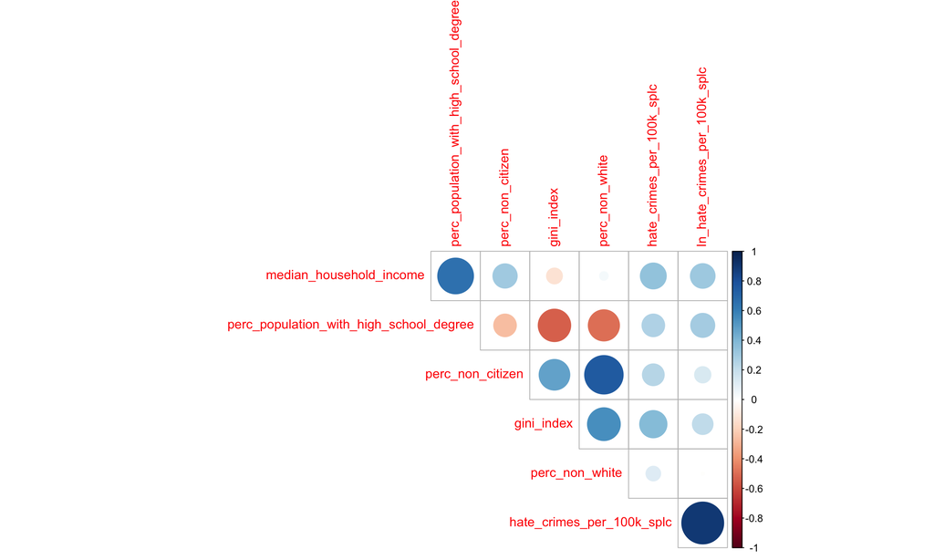

```r
hate_crime %>%
  drop_na() %>%
  dplyr::select(-state,-unemployment,-urbanization) %>%  #removing factor variables
  cor() %>%
  corrplot::corrplot(method = "circle", type = "upper", diag = FALSE)
```

##### Correlation Plots bw Predictors and Outcome

```r
a = ggscatter(hate_crime, x = "median_household_income", y = "hate_crimes_per_100k_splc",
          add = "reg.line", conf.int = TRUE,
          cor.coef = TRUE, cor.method = "pearson",
          xlab = "Median Household Income", ylab = "Hate Crime Rate (per 100k pop.)")

b = ggscatter(hate_crime, x = "perc_population_with_high_school_degree", y = "hate_crimes_per_100k_splc",
          add = "reg.line", conf.int = TRUE,
          cor.coef = TRUE, cor.method = "pearson",
          xlab = "% of People 25+ with High School Degree", ylab = "Hate Crime Rate (per 100k pop.)")

c = ggscatter(hate_crime, x = "perc_non_citizen", y = "hate_crimes_per_100k_splc",
          add = "reg.line", conf.int = TRUE,
          cor.coef = TRUE, cor.method = "pearson",
          xlab = "% of People Non-US Citizens", ylab = "Hate Crime Rate (per 100k pop.)")

d = ggscatter(hate_crime, x = "gini_index", y = "hate_crimes_per_100k_splc",
          add = "reg.line", conf.int = TRUE,
          cor.coef = TRUE, cor.method = "pearson",
          xlab = "Income Inequality Index (0-100)", ylab = "Hate Crime Rate (per 100k pop.)")

e = ggscatter(hate_crime, x = "perc_non_white", y = "hate_crimes_per_100k_splc",
          add = "reg.line", conf.int = TRUE,
          cor.coef = TRUE, cor.method = "pearson",
          xlab = "% of People Non-White", ylab = "Hate Crime Rate (per 100k pop.)")
```

From our results, we observe that predictors, “gini_index” and “median_household_income” have the highest correlations to our outcome of interest.

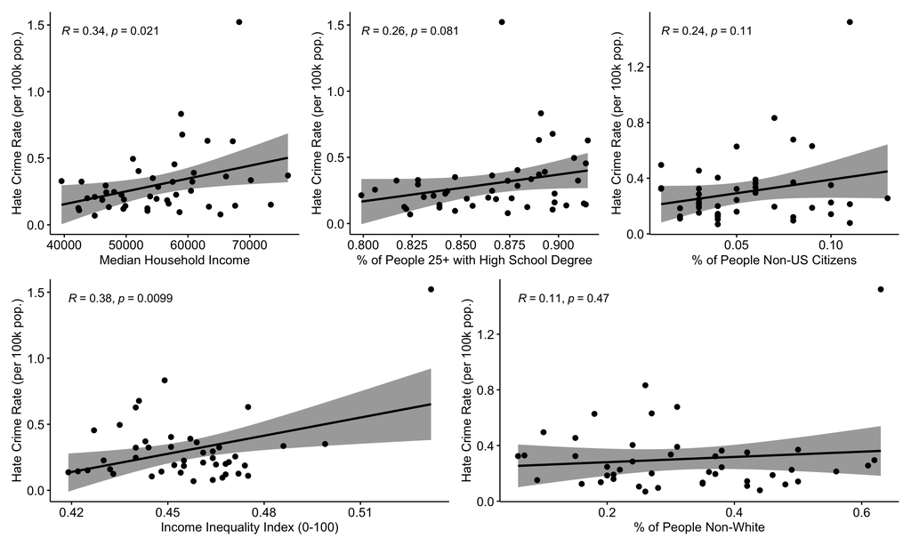

```r
(a + b + c) / (d + e)
```

#### Multicollinearity (Nikhita)

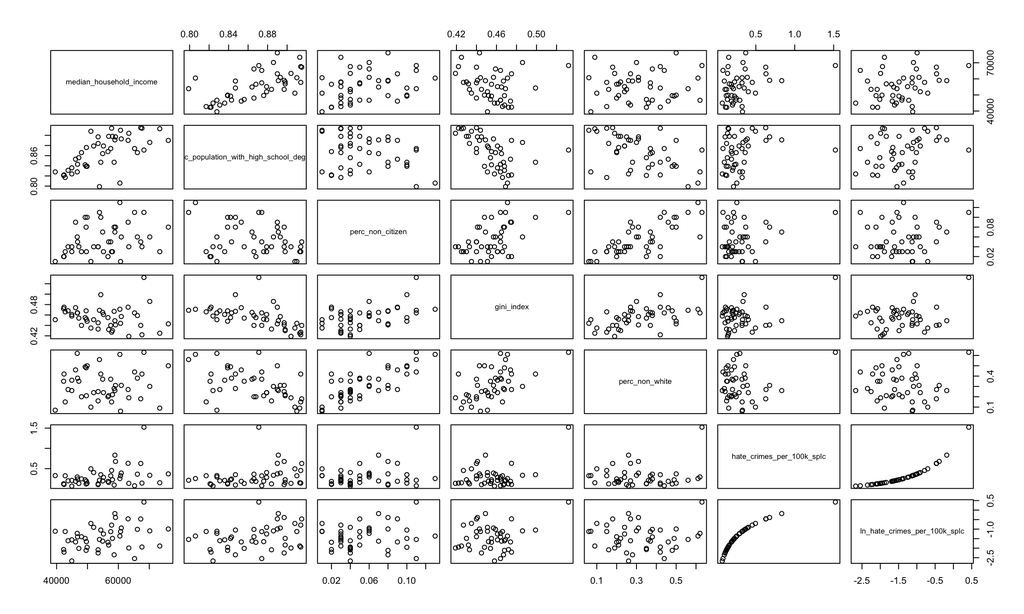

```r
# Scatter plot showing associations between numeric variables

hate_crime %>%
  dplyr::select(-state,-unemployment,-urbanization) %>%
  pairs()
```

#### Calculating VIF for all the predictors

```r
hate_crime_tidy = hate_crime %>% drop_na()

# fitting MLR model on tidy data without state variable
mult_fit <- lm(hate_crimes_per_100k_splc ~ unemployment + urbanization + median_household_income + perc_population_with_high_school_degree + perc_non_citizen + gini_index + perc_non_white, data = hate_crime_tidy)

vif(mult_fit) %>% knitr::kable()
```

|  | x |
| --- | --- |
| unemploymentlow | 1.426492 |
| urbanizationhigh | 1.983246 |
| median_household_income | 3.108161 |
| perc_population_with_high_school_degree | 3.895361 |
| perc_non_citizen | 3.728286 |
| gini_index | 1.845436 |
| perc_non_white | 3.236419 |

All the predictors have a VIF below 5. This suggests that it would not be problematic to include them in the construction of the model. However, the correlation analysis shows that variables `perc_non_white` and `perc_non_citizen` have a moderate linear relationship with a correlation coefficient of 0.75.

##### Interaction between income equality and unemployment

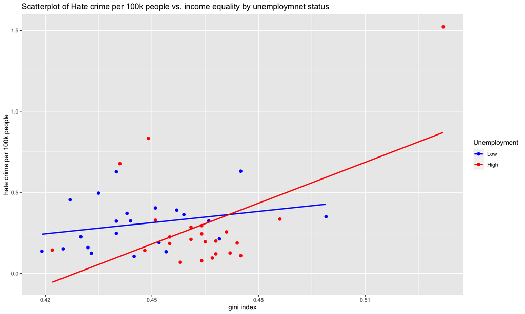

```r
#Scatter plot - Hate_crime_per_100k_splc vs. gini index by unemploymnet
ggplot(hate_crimedf, aes(x = gini_index, y = hate_crimes_per_100k_splc, colour = factor(unemployment))) +
  geom_point(size = 2) +
  geom_smooth(method = "lm", se = F,
              aes(group = factor(unemployment),
                  color = factor(unemployment))) +
  labs(title = "Scatterplot of Hate crime per 100k people vs. income equality by unemploymnet status",
       x = "gini index", y = "hate crime per 100k people") +
  scale_color_manual(name = "Unemployment", labels = c("Low", "High"), values = c("blue", "red"))
```

```r
reg1 <- lm(hate_crimes_per_100k_splc ~ gini_index*factor(unemployment), data = hate_crimedf)
summary(reg1)
```

```
##
## Call:
## lm(formula = hate_crimes_per_100k_splc ~ gini_index * factor(unemployment),
##     data = hate_crimedf)
##
## Residuals:
##      Min       1Q   Median       3Q      Max
## -0.28142 -0.14375 -0.04337  0.06089  0.66008
##
## Coefficients:
##                                  Estimate Std. Error t value Pr(>|t|)
## (Intercept)                       -0.7256     1.1896  -0.610   0.5453
## gini_index                         2.3090     2.6588   0.868   0.3902
## factor(unemployment)1             -2.8730     1.6475  -1.744   0.0887 .
## gini_index:factor(unemployment)1   6.0906     3.6185   1.683   0.0999 .
## ---
## Signif. codes:  0 '***' 0.001 '**' 0.01 '*' 0.05 '.' 0.1 ' ' 1
##
## Residual standard error: 0.2282 on 41 degrees of freedom
## Multiple R-squared:  0.2334, Adjusted R-squared:  0.1773
## F-statistic:  4.16 on 3 and 41 DF,  p-value: 0.0116
```

There is no significant interaction at 5% significance level. The relationship between hate crime per 100k people and income equality does not vary bt unemployment status. Hence, stratified analysis is not included.

##### Interaction between income equality and urbanization

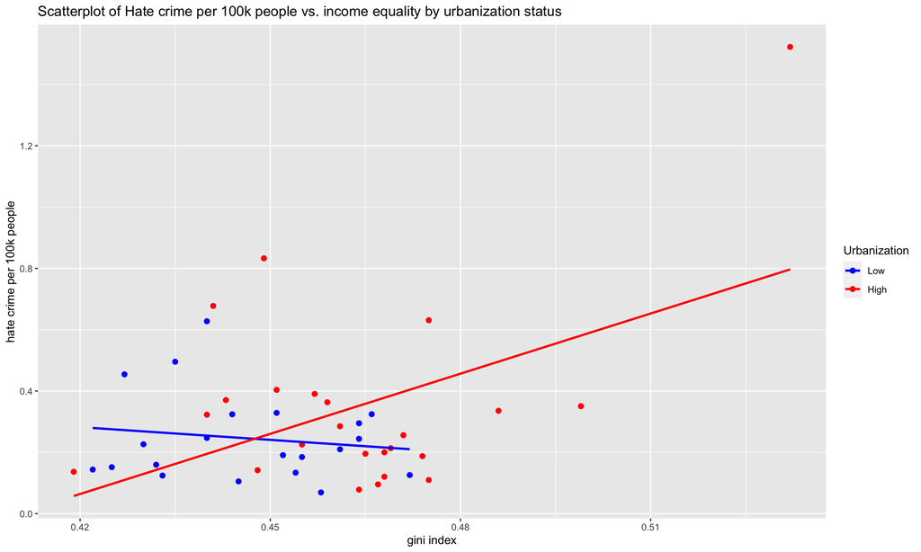

```r
#Scatter plot - Hate_crime_per_100k_splc vs. gini index by urbanization
ggplot(hate_crimedf, aes(x = gini_index, y = hate_crimes_per_100k_splc, colour = factor(urbanization))) +
  geom_point(size = 2) +
  geom_smooth(method = "lm", se = F,
              aes(group = factor(urbanization),
                  color = factor(urbanization))) +
  labs(title = "Scatterplot of Hate crime per 100k people vs. income equality by urbanization status",
       x = "gini index", y = "hate crime per 100k people") +
  scale_color_manual(name = "Urbanization", labels = c("Low", "High"), values = c("blue", "red"))
```

```r
reg2 <- lm(hate_crimes_per_100k_splc ~ gini_index*factor(urbanization), data = hate_crimedf)
summary(reg2)
```

```
##
## Call:
## lm(formula = hate_crimes_per_100k_splc ~ gini_index * factor(urbanization),
##     data = hate_crimedf)
##
## Residuals:
##      Min       1Q   Median       3Q      Max
## -0.31410 -0.14242 -0.04718  0.08940  0.72556
##
## Coefficients:
##                                  Estimate Std. Error t value Pr(>|t|)
## (Intercept)                        0.8628     1.5325   0.563   0.5765
## gini_index                        -1.3825     3.4328  -0.403   0.6892
## factor(urbanization)1             -3.5465     1.8361  -1.932   0.0603 .
## gini_index:factor(urbanization)1   7.9247     4.0649   1.950   0.0581 .
## ---
## Signif. codes:  0 '***' 0.001 '**' 0.01 '*' 0.05 '.' 0.1 ' ' 1
##
## Residual standard error: 0.2302 on 41 degrees of freedom
## Multiple R-squared:   0.22,  Adjusted R-squared:  0.1629
## F-statistic: 3.855 on 3 and 41 DF,  p-value: 0.01612
```

There is no significant interaction at 5% significance level.The relationship between hate crime per 100k people and income equality does not vary by urbanization status. Hence, stratified analysis is not included.

# Model diagnostics

Check model assumptions and goodness of fit (Vihar Desu)

```r
hate_crime =
  hate_crime %>%
  drop_na() %>%
  dplyr::select(-state)

hate_crime_fit = lm(hate_crimes_per_100k_splc ~., data = hate_crime)
summary(hate_crime_fit)
```

```
##
## Call:
## lm(formula = hate_crimes_per_100k_splc ~ ., data = hate_crime)
##
## Residuals:
##      Min       1Q   Median       3Q      Max
## -0.21283 -0.04959  0.00530  0.03604  0.32897
##
## Coefficients:
##                                           Estimate Std. Error t value Pr(>|t|)
## (Intercept)                             -2.644e+00  1.061e+00  -2.492  0.01744
## unemploymentlow                         -5.250e-02  3.558e-02  -1.476  0.14872
## urbanizationhigh                        -6.284e-02  4.152e-02  -1.514  0.13887
## median_household_income                 -7.984e-08  2.917e-06  -0.027  0.97831
## perc_population_with_high_school_degree  2.008e+00  9.488e-01   2.117  0.04128
## perc_non_citizen                         8.814e-01  9.181e-01   0.960  0.34344
## gini_index                               3.596e+00  1.069e+00   3.363  0.00184
## perc_non_white                           3.125e-02  1.796e-01   0.174  0.86286
## ln_hate_crimes_per_100k_splc             3.010e-01  2.761e-02  10.901 5.89e-13
##
## (Intercept)                             *
## unemploymentlow
## urbanizationhigh
## median_household_income
## perc_population_with_high_school_degree *
## perc_non_citizen
## gini_index                              **
## perc_non_white
## ln_hate_crimes_per_100k_splc            ***
## ---
## Signif. codes:  0 '***' 0.001 '**' 0.01 '*' 0.05 '.' 0.1 ' ' 1
##
## Residual standard error: 0.09845 on 36 degrees of freedom
## Multiple R-squared:  0.8747, Adjusted R-squared:  0.8468
## F-statistic: 31.41 on 8 and 36 DF,  p-value: 5.285e-14
```

Box-Cox without transformation

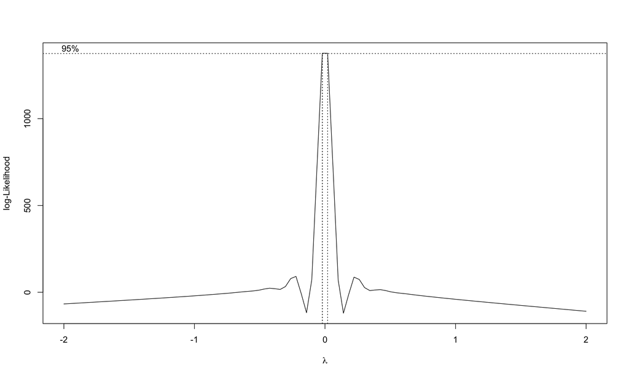

```r
hate_crime_fit %>%
  MASS::boxcox()
```

Take log transformation

```r
hate_crime_log_fit = lm(log(hate_crimes_per_100k_splc) ~ . ,
                    data = hate_crime)
```

## QQ plot for model with transformation and without transformation

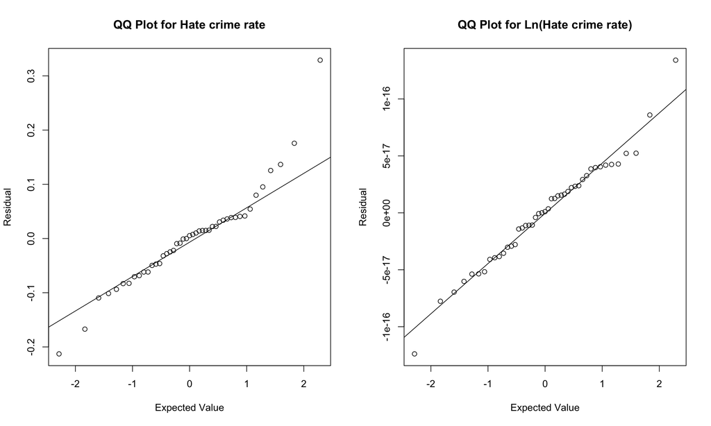

```r
par(mfrow = c(1, 2))

# without transformation
qqnorm(resid(hate_crime_fit), xlab = "Expected Value", ylab = "Residual", main = "")
qqline(resid(hate_crime_fit))
title("QQ Plot for Hate crime rate")

# with transformation
qqnorm(resid(hate_crime_log_fit), xlab = "Expected Value", ylab = "Residual", main = "")
qqline(resid(hate_crime_log_fit))
title("QQ Plot for Ln(Hate crime rate)")
```

# Model Selection

Stepwise selection

```r
step(hate_crime_fit, direction = "backward")
```

```
## Start:  AIC=-200.68
## hate_crimes_per_100k_splc ~ unemployment + urbanization + median_household_income +
##     perc_population_with_high_school_degree + perc_non_citizen +
##     gini_index + perc_non_white + ln_hate_crimes_per_100k_splc
##
##                                           Df Sum of Sq     RSS     AIC
## - median_household_income                  1   0.00001 0.34893 -202.68
## - perc_non_white                           1   0.00029 0.34922 -202.64
## - perc_non_citizen                         1   0.00893 0.35786 -201.54
## <none>                                                 0.34893 -200.68
## - unemployment                             1   0.02111 0.37003 -200.04
## - urbanization                             1   0.02220 0.37113 -199.90
## - perc_population_with_high_school_degree  1   0.04342 0.39235 -197.40
## - gini_index                               1   0.10963 0.45856 -190.38
## - ln_hate_crimes_per_100k_splc             1   1.15185 1.50078 -137.03
##
## Step:  AIC=-202.68
## hate_crimes_per_100k_splc ~ unemployment + urbanization + perc_population_with_high_school_degree +
##     perc_non_citizen + gini_index + perc_non_white + ln_hate_crimes_per_100k_splc
##
##                                           Df Sum of Sq     RSS     AIC
## - perc_non_white                           1   0.00029 0.34922 -204.64
## - perc_non_citizen                         1   0.00973 0.35866 -203.44
## <none>                                                 0.34893 -202.68
## - unemployment                             1   0.02144 0.37038 -202.00
## - urbanization                             1   0.02248 0.37141 -201.87
## - perc_population_with_high_school_degree  1   0.08754 0.43648 -194.61
## - gini_index                               1   0.11054 0.45948 -192.29
## - ln_hate_crimes_per_100k_splc             1   1.15443 1.50336 -138.95
##
## Step:  AIC=-204.64
## hate_crimes_per_100k_splc ~ unemployment + urbanization + perc_population_with_high_school_degree +
##     perc_non_citizen + gini_index + ln_hate_crimes_per_100k_splc
##
##                                           Df Sum of Sq     RSS     AIC
## <none>                                                 0.34922 -204.64
## - perc_non_citizen                         1   0.01971 0.36893 -204.17
## - urbanization                             1   0.02273 0.37195 -203.80
## - unemployment                             1   0.02364 0.37286 -203.69
## - perc_population_with_high_school_degree  1   0.09136 0.44058 -196.19
## - gini_index                               1   0.11260 0.46182 -194.07
## - ln_hate_crimes_per_100k_splc             1   1.15426 1.50348 -140.95
```

```
##
## Call:
## lm(formula = hate_crimes_per_100k_splc ~ unemployment + urbanization +
##     perc_population_with_high_school_degree + perc_non_citizen +
##     gini_index + ln_hate_crimes_per_100k_splc, data = hate_crime)
##
## Coefficients:
##                             (Intercept)
##                                -2.60635
##                         unemploymentlow
##                                -0.05393
##                        urbanizationhigh
##                                -0.06325
## perc_population_with_high_school_degree
##                                 1.95945
##                        perc_non_citizen
##                                 0.96767
##                              gini_index
##                                 3.61009
##            ln_hate_crimes_per_100k_splc
##                                 0.30090
```

```r
#lm(hate_crimes_per_100k_splc ~ perc_population_with_high_school_degree + gini_index, data = hate_crime)
```

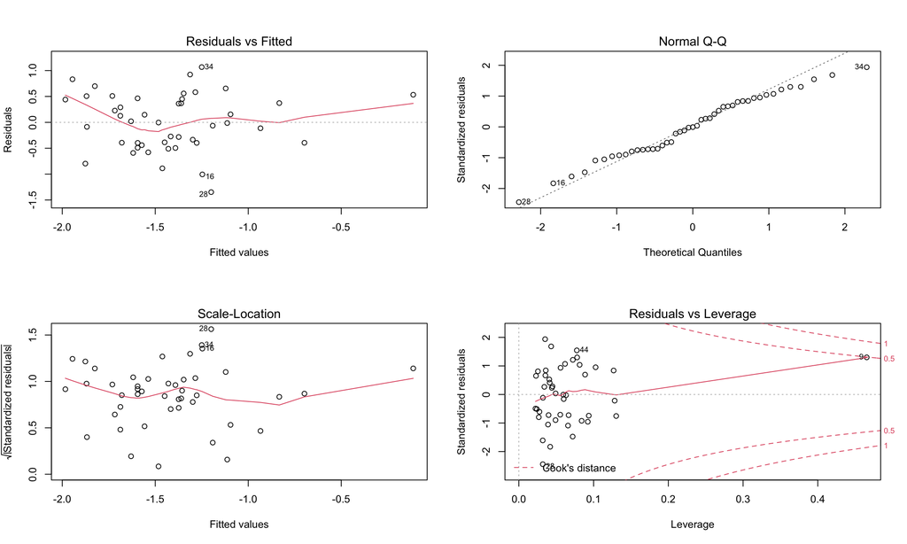

```r
stepwise_log_fit =
  lm(log(hate_crimes_per_100k_splc) ~ perc_population_with_high_school_degree + gini_index, data = hate_crime)
par(mfrow = c(2, 2))
plot(stepwise_log_fit)
```